# Veritas AI

[figure not shown]

Veritas AI: an open-source research assistant you can check

Joseph Frimpong · Oded Asiedu · Huihuo Zheng Team Veritas AI OSI Hackathon 2026 — October 22, 2026

## Team Veritas AI

We built Veritas at the **OSI Hackathon 2026**.

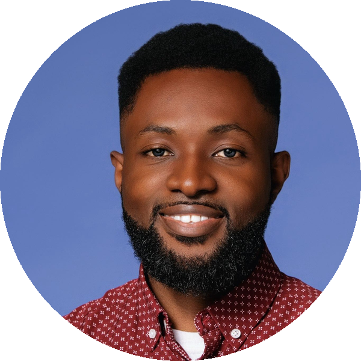

Joseph Frimpong

Argonne National Laboratory

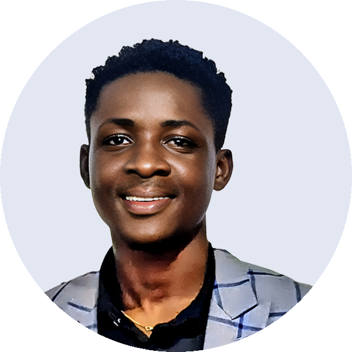

Oded Asiedu

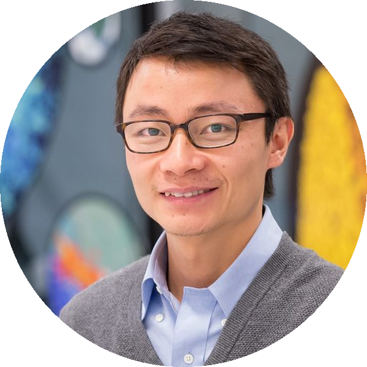

Huihuo Zheng

Argonne National Laboratory

## Three places, no link

A scientist’s knowledge sits in **three places that do not talk to each other**:

[figure not shown]

**Reference manager**

[figure not shown]

**Notes**

[figure not shown]

**New preprints**

[figure not shown]

- Chat assistants answer from none of them, and cite papers you cannot open

[figure not shown]

- Veritas joins the three on **your own device** and links every answer to a paper or note you can check

## Reading radar

[figure not shown]

[figure not shown]

- Starts from **the papers you wrote** and your interests

[figure not shown]

- Watches arXiv, journals, **RSS feeds** and Valency Bond

[figure not shown]

- Keeps only new papers close to your work, and says which of your papers each one matches

[figure not shown]

- Like or dislike a paper: it **learns your taste**

## Chat with citations

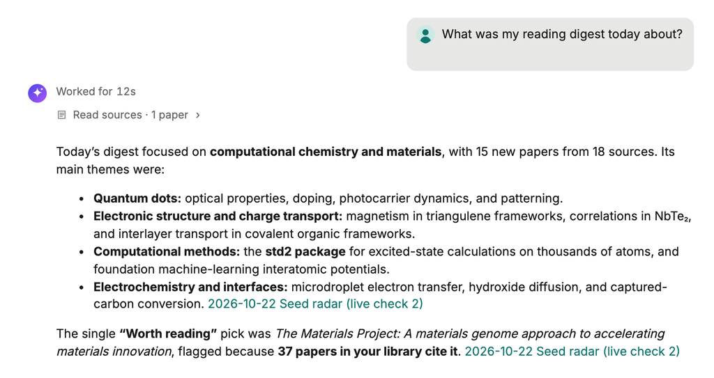

[figure not shown]

- Ask about your library, your notes or **today’s digest**

[figure not shown]

- Every claim cites a paper or note

[figure not shown]

- Sources on or off per question: Papers, Notes, Scholarly, Web, **Valency**

## Links that open

[figure not shown]

[figure not shown]

- A DOI opens **the PDF in your library**

[figure not shown]

- Else a **legal open-access copy** (OpenAlex), else the abstract

[figure not shown]

- Publishers that block bots and frames no longer break the link

## Connects to

**Your sources**

- Zotero library
- Obsidian notes

[figure not shown]

- Any folder of notes and PDFs

**The literature**

- arXiv
- OpenAlex and journals
- RSS feeds you follow
- Valency Bond: 500M+ papers, ChemRxiv included

**Your AI**

[figure not shown]

- Runs on your own device
- Through MCP, your library plugs into any AI chat that supports it
- Claude
- ChatGPT and others

## Veritas AI

Before the event we had built the Zotero and Obsidian tools. **During the hackathon** we built:

[figure not shown]

- the reading radar and daily digest, with tools the assistant uses to read it

[figure not shown]

- links that open papers directly, and the Valency Bond connector

[figure not shown]

- a knowledge base of 31 research personas, and Veritas itself as one open-source project

[figure not shown]

- **Next:** persona agents: pick fields such as HPC and computational chemistry, and Veritas answers from each angle

[figure not shown]

**Open source (MIT):** github.com/frimpsjoek/veritas-ai

[figure not shown]